# 2019-10-22 Horror Movies

First of all, let’s read in the data and view the columns we currently have

```r
horror_movies_raw <- readr::read_csv("https://raw.githubusercontent.com/rfordatascience/tidytuesday/master/data/2019/2019-10-22/horror_movies.csv")
head(horror_movies_raw,6)
```

```
## # A tibble: 6 x 12
##   title genres release_date release_country movie_rating review_rating
##   <chr> <chr>  <chr>        <chr>           <chr>                <dbl>
## 1 Gut … Drama… 26-Oct-12    USA             <NA>                   3.9
## 2 The … Horror 13-Jan-17    USA             <NA>                  NA
## 3 Slee… Horror 21-Oct-17    Canada          <NA>                  NA
## 4 Trea… Comed… 23-Apr-13    USA             NOT RATED              3.7
## 5 Infi… Crime… 10-Apr-15    USA             <NA>                   5.8
## 6 In E… Horro… 2017         UK              <NA>                  NA
## # … with 6 more variables: movie_run_time <chr>, plot <chr>, cast <chr>,
## #   language <chr>, filming_locations <chr>, budget <chr>
```

From a quick glance it looks like we can make the following changes

- Convert release_date to date
- Extract year from title
- Seperate currency from budget column
- Extract minutes from movie_run_time
- Extract country from filming location
- Extract director from Plot

The following columns contain multiple entries so are difficult splitting out at this early stage. Might be worth splitting out if we try use xgbBoost to predict review_rating (for example).

- genres
- cast

```r
horror_movies <- horror_movies_raw %>%
  extract(title,"year","\\((\\d\\d\\d\\d)\\)$",remove = FALSE,convert = TRUE) %>%
  extract(plot,"directed_by","^Directed by (.*)\\.\\sWith",remove = FALSE) %>%
  mutate(release_date = dmy(release_date),
         release_month = month(release_date),
         release_year = year(release_date),
         next_halloween = if_else(release_month > 10,
                                  ymd(glue("{release_year +1}-10-31")),
                                  ymd(glue("{release_year}-10-31"))),
         days_before_halloween = next_halloween - release_date,
         currency = str_extract(budget,"^\\D*"),
         budget = parse_number(budget),
         filming_country = str_trim(str_extract(filming_locations,"(?!.*,).*$")),
         movie_run_time_mins = parse_number(movie_run_time),
         movie_run_time_bins = fct_explicit_na(cut(movie_run_time_mins, 4,rm.na = TRUE))
         )
  glimpse(horror_movies)
```

```
## Observations: 3,328
## Variables: 22
## $ title                 <chr> "Gut (2012)", "The Haunting of Mia Moss (2…
## $ year                  <int> 2012, 2017, 2017, 2013, 2015, 2017, 2013, …
## $ genres                <chr> "Drama| Horror| Thriller", "Horror", "Horr…
## $ release_date          <date> 2012-10-26, 2017-01-13, 2017-10-21, 2013-…
## $ release_country       <chr> "USA", "USA", "Canada", "USA", "USA", "UK"…
## $ movie_rating          <chr> NA, NA, NA, "NOT RATED", NA, NA, "NOT RATE…
## $ review_rating         <dbl> 3.9, NA, NA, 3.7, 5.8, NA, 5.1, 6.5, 4.6, …
## $ movie_run_time        <chr> "91 min", NA, NA, "82 min", "80 min", "93 …
## $ plot                  <chr> "Directed by Elias. With Jason Vail, Nicho…
## $ directed_by           <chr> "Elias", "Jake Zelch", "David Briggs", "M.…
## $ cast                  <chr> "Jason Vail|Nicholas Wilder|Sarah Schoofs|…
## $ language              <chr> "English", "English", "English", "English"…
## $ filming_locations     <chr> "New York, USA", NA, "Sudbury, Ontario, Ca…
## $ budget                <dbl> NA, 30000, NA, NA, NA, 3400000, NA, NA, NA…
## $ release_month         <dbl> 10, 1, 10, 4, 4, NA, 6, 4, 5, 10, 7, 5, 4,…
## $ release_year          <dbl> 2012, 2017, 2017, 2013, 2015, NA, 2014, 20…
## $ next_halloween        <date> 2012-10-31, 2017-10-31, 2017-10-31, 2013-…
## $ days_before_halloween <drtn> 5 days, 291 days, 10 days, 191 days, 204 …
## $ currency              <chr> NA, "$", NA, NA, NA, "$", NA, NA, NA, NA, …
## $ filming_country       <chr> "USA", NA, "Canada", "USA", NA, NA, NA, "J…
## $ movie_run_time_mins   <dbl> 91, NA, NA, 82, 80, 93, 90, 117, 90, 138, …
## $ movie_run_time_bins   <fct> "(54,96]", "(Missing)", "(Missing)", "(54,…
```

```r
  skimr=(horror_movies)
```

First question I have: does the review_ratings increase as the number of movies a director films increases?

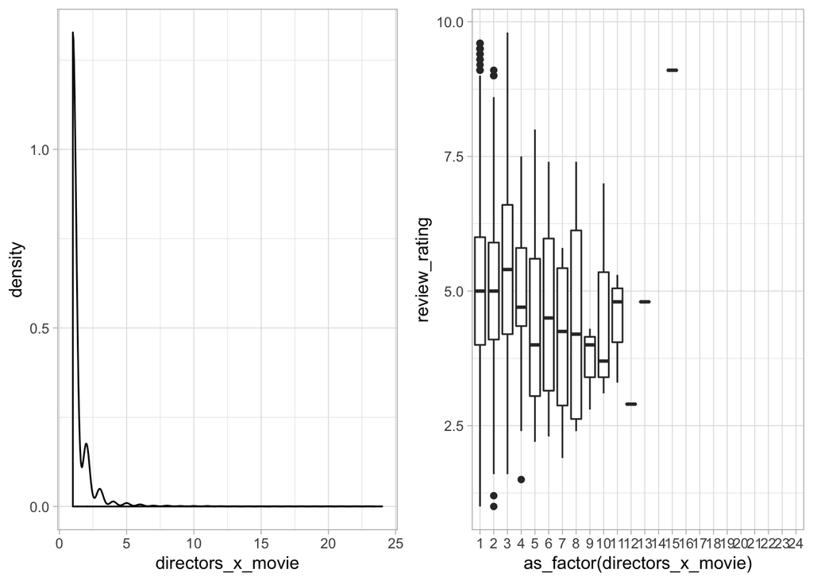

```r
# horror_movies1 %>% group_by(directed_by) %>% summarise(mean = mean(review_rating,na.rm = T),n = n()) %>% arrange(desc(n)) %>% head()

horror_movies1 <- horror_movies %>%
  group_by(directed_by) %>%
  mutate(directors_x_movie = rank(release_date,ties.method = "first")) %>% ungroup()

G1 <- horror_movies1 %>% ggplot(aes(directors_x_movie)) + geom_density() # shows majority of direcors only film one horror movie
G2 <- horror_movies1 %>% ggplot(aes(x = as_factor(directors_x_movie),y = review_rating)) + geom_boxplot()
grid.arrange(G1,G2,nrow = 1)
```

Nope, there doesn’t look to be much of a relationship. Let’s compute an analysis of variance.

```r
horror_movies1 %>% lm(review_rating ~ directors_x_movie, data = .) %>% anova() %>% tidy()
```

```
## # A tibble: 2 x 6
##   term                 df   sumsq meansq statistic p.value
##   <chr>             <int>   <dbl>  <dbl>     <dbl>   <dbl>
## 1 directors_x_movie     1    4.50   4.50      2.07   0.150
## 2 Residuals          3074 6679.     2.17     NA     NA
```

This p value here indicates that the variance of review_rating cannot be explained by the number of movies a director has filmed.

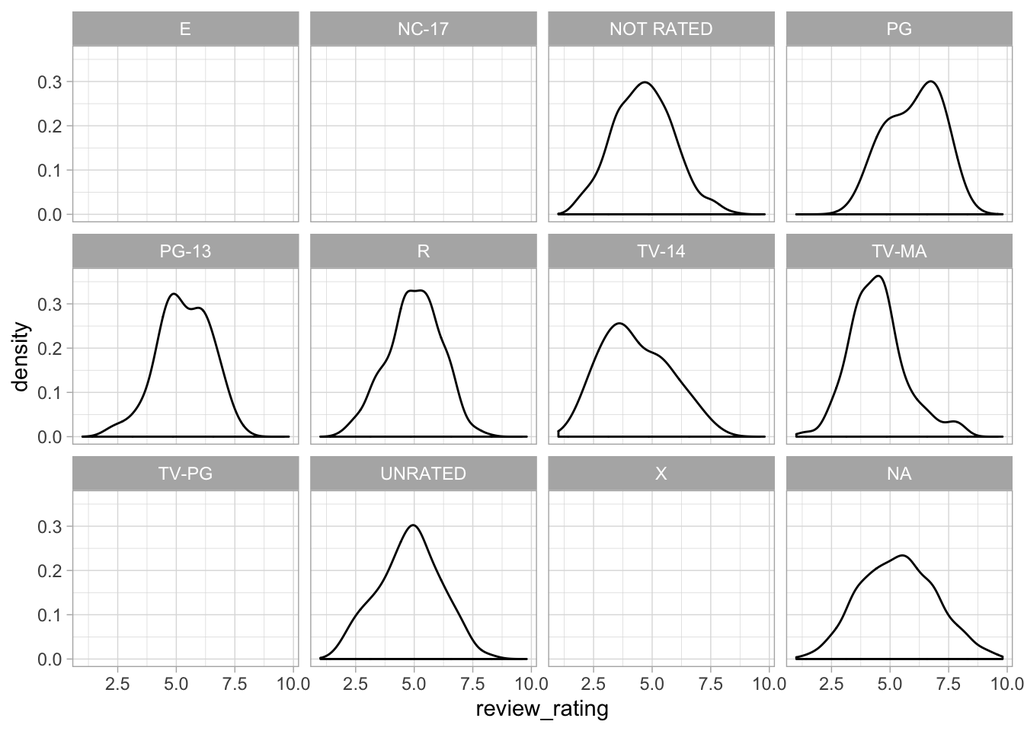

```r
horror_movies %>% ggplot(aes(review_rating)) + geom_density() + facet_wrap(~movie_rating)
```

```r
shapiro.test(horror_movies$review_rating)
```

```
##
##  Shapiro-Wilk normality test
##
## data:  horror_movies$review_rating
## W = 0.99586, p-value = 1.533e-07
```

```r
horror_movies %>% group_by(movie_run_time_bins) %>% summarise(avg = mean(review_rating,na.rm = TRUE))
```

```
## # A tibble: 5 x 2
##   movie_run_time_bins   avg
##   <fct>               <dbl>
## 1 (11.8,54]            5.67
## 2 (54,96]              4.82
## 3 (96,138]             5.53
## 4 (138,180]            5.86
## 5 (Missing)            5.56
```

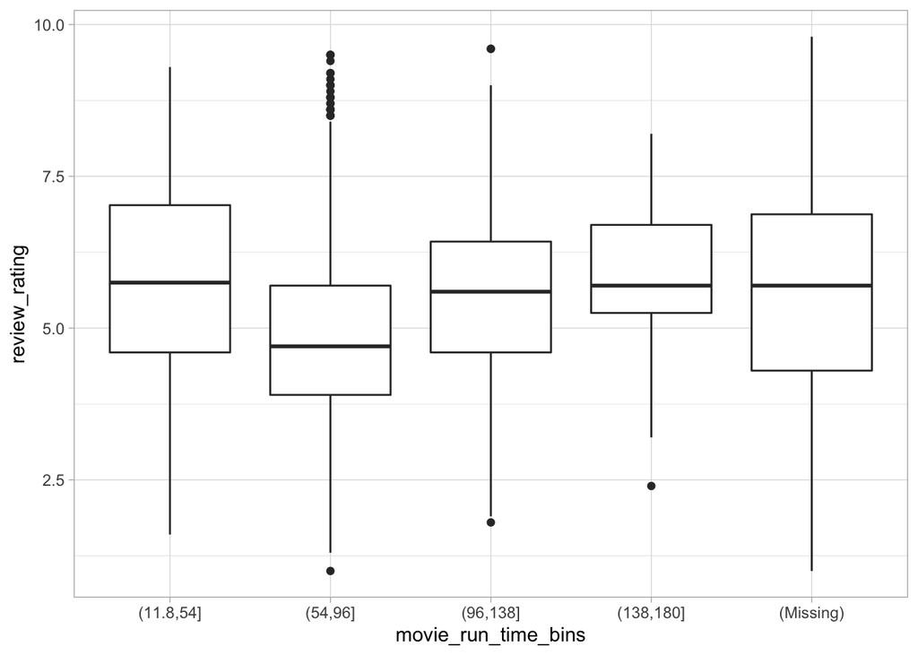

```r
horror_movies %>% ggplot(aes(x = movie_run_time_bins, y = review_rating)) + geom_boxplot()
```

```r
horror_movies %>% aov(review_rating ~ movie_run_time_bins, data = .) %>% summary()
```

```
##                       Df Sum Sq Mean Sq F value Pr(>F)
## movie_run_time_bins    4    381   95.28   46.43 <2e-16 ***
## Residuals           3071   6302    2.05
## ---
## Signif. codes:  0 '***' 0.001 '**' 0.01 '*' 0.05 '.' 0.1 ' ' 1
## 252 observations deleted due to missingness
```

```r
horror_movies %>% lm(review_rating ~ year, data = .) %>% summary()
```

```
##
## Call:
## lm(formula = review_rating ~ year, data = .)
##
## Residuals:
##     Min      1Q  Median      3Q     Max
## -4.1868 -1.0458 -0.0458  0.9771  5.6637
##
## Coefficients:
##               Estimate Std. Error t value Pr(>|t|)
## (Intercept) -77.435874  17.489928  -4.427 9.87e-06 ***
## year          0.040963   0.008683   4.718 2.49e-06 ***
## ---
## Signif. codes:  0 '***' 0.001 '**' 0.01 '*' 0.05 '.' 0.1 ' ' 1
##
## Residual standard error: 1.469 on 3074 degrees of freedom
##   (252 observations deleted due to missingness)
## Multiple R-squared:  0.007188,   Adjusted R-squared:  0.006865
## F-statistic: 22.26 on 1 and 3074 DF,  p-value: 2.491e-06
```

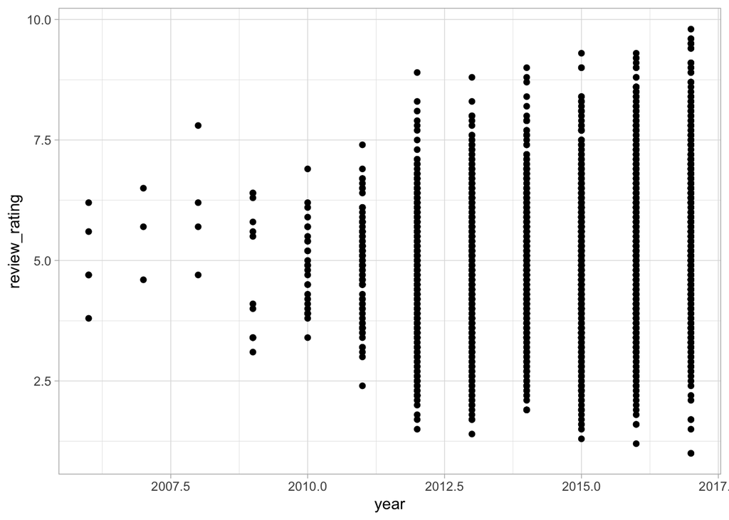

```r
horror_movies %>% filter(year >2005)%>% ggplot(aes(x = year, y = review_rating))  + geom_point()
```

Let’s now look at the review rating by genre and see if there are any significant differences between genres.

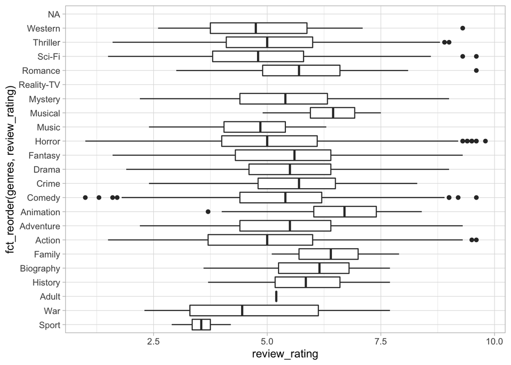

```r
genre <- horror_movies %>% select(genres,language,movie_run_time_mins,review_rating) %>%
  separate_rows(genres,sep = "\\| ?") %>% mutate(genres = fct_reorder(genres,review_rating))

genre %>% ggplot(aes(x = fct_reorder(genres,review_rating), y = review_rating)) + geom_boxplot() + coord_flip()
```

```r
aov<- aov(review_rating ~ genres,genre)
summary(aov)
```

```
##               Df Sum Sq Mean Sq F value Pr(>F)
## genres        20    363  18.160   8.888 <2e-16 ***
## Residuals   7084  14474   2.043
## ---
## Signif. codes:  0 '***' 0.001 '**' 0.01 '*' 0.05 '.' 0.1 ' ' 1
## 421 observations deleted due to missingness
```

We will use Tukey’s Honest Significant Difference test to look at pairswise differences. This a parametric approach so we do need to check the data does not violate the assumptions. - Normality - Constant variance

As there are many groups, I will look at the residuals.

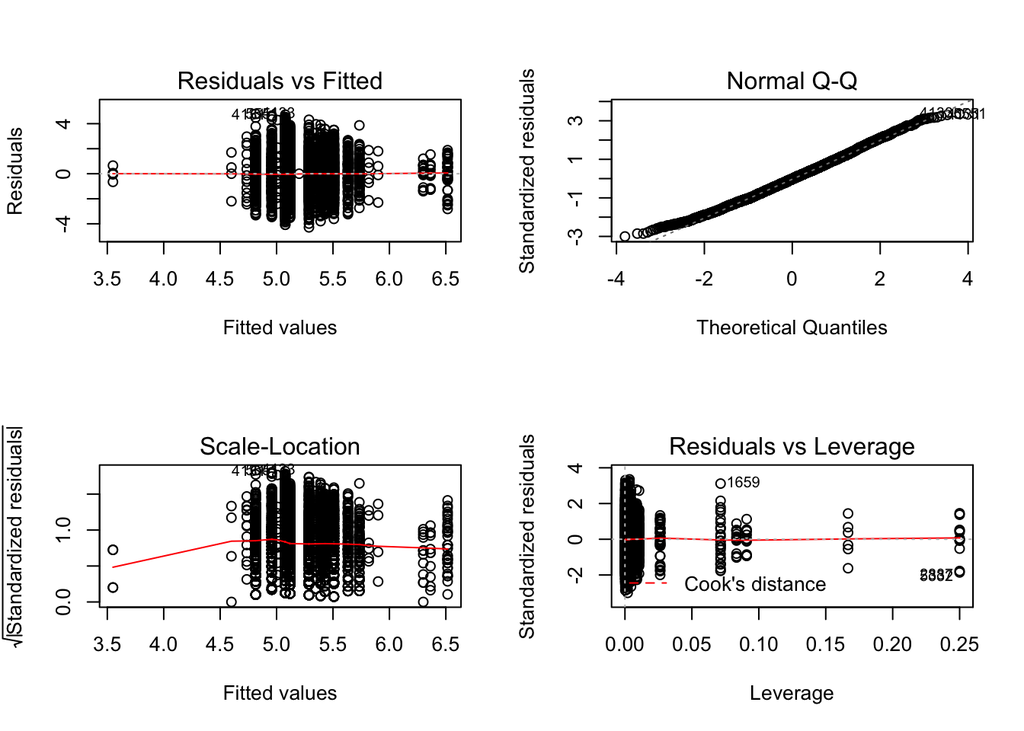

```r
par(mfrow=c(2,2))
plot(aov)
```

Looks like the assumption for constant variance is slightly violated by the examining the first plot. The variance of residuals increases between review ratings between 5 and 5.5.

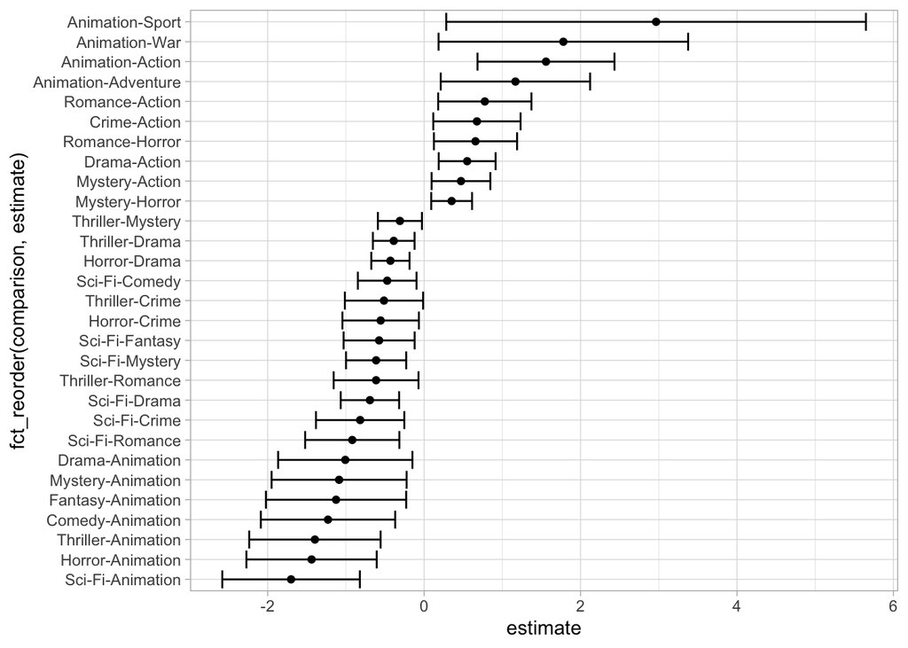

```r
tukey <-TukeyHSD(aov) %>% tidy %>% arrange(adj.p.value)

tukey %>% filter(adj.p.value < 0.05) %>% ggplot(aes(x = fct_reorder(comparison,estimate), y = estimate )) + geom_point() +
  geom_errorbar(aes(ymin = conf.low, ymax = conf.high)) + coord_flip()
```

I’d be interested to know what movies have genres Horror and Sport.

```r
horror_movies %>% filter(str_detect(genres,"Sport")) %>% arrange(review_rating) %>% kable()
```

| title | year | genres | release_date | release_country | movie_rating | review_rating | movie_run_time | plot | directed_by | cast | language | filming_locations | budget | release_month | release_year | next_halloween | days_before_halloween | currency | filming_country | movie_run_time_mins | movie_run_time_bins |
| --- | --- | --- | --- | --- | --- | --- | --- | --- | --- | --- | --- | --- | --- | --- | --- | --- | --- | --- | --- | --- | --- |
| Brutal (2014) | 2014 | Action\| Drama\| Horror\| Sci-Fi\| Sport | 2014-01-05 | USA | TV-MA | 2.9 | 90 min | Directed by Donald Lawrence Flaherty, Colin Follenweider. With Morgan Benoit, Jeff Hatch, David Mattey, Renata Green-Gaber. Abducted without explanation, two men are forced into a daily steel cage bra… | Donald Lawrence Flaherty, Colin Follenweider | Morgan Benoit\|Jeff Hatch\|David Mattey\|Renata Green-Gaber\|Stacy Jorgensen\|Mario Kenyon\|Christina Brooks\|Collin Armstrong\|Gary Backlund\|Eric Bivoino\|Jim Fath\|Andrew Flaherty\|Daniel Headecker… | English | Central City Studio, Los Angeles, California, USA | NA | 1 | 2014 | 2014-10-31 | 299 days | NA | USA | 90 | (54,96] |
| Downhill (2016) | 2016 | Action\| Horror\| Sport\| Thriller | 2017-01-14 | Japan | NA | 3.5 | 82 min | Directed by Patricio Valladares. With Natalie Burn, Bryce Draper, Eyal Meyer, Ariel Levy. After his best friend dies in a racing accident, biking star Joe agrees to go back on the wheels for an exhibi… | Patricio Valladares | Natalie Burn\|Bryce Draper\|Eyal Meyer\|Ariel Levy\|Luke Massy\|Andrés Gómez\|Vittorio Farfan\|Ignacia Allamand\|Rodrigo Huepe\|Matías López\|Yuri Caceres\|Lisseth Candia Encina\|Cristian Cuentrejo\|E… | Spanish\|English | Las Termas de Chillán, Chile | NA | 1 | 2017 | 2017-10-31 | 290 days | NA | Chile | 82 | (54,96] |
| Monster Brawl (2011) | 2011 | Action\| Comedy\| Horror\| Sport | 2012-03-30 | USA | NOT RATED | 3.6 | 89 min | Directed by Jesse Thomas Cook. With Dave Foley, Art Hindle, Robert Maillet, Jimmy Hart. Eight classic monsters fight to the death in an explosive wrestling tournament set inside an abandoned and curse… | Jesse Thomas Cook | Dave Foley\|Art Hindle\|Robert Maillet\|Jimmy Hart\|Herb Dean\|Kevin Nash\|Lance Henriksen\|Jason David Brown\|Rj Skinner\|Rico Montana\|Courtney Rush\|Kelly Couture\|Jason Deline\|Ari Millen\|John Ge… | English\|Egyptian (Ancient) | Epping, Ontario, Canada | 2e+05 | 3 | 2012 | 2012-10-31 | 215 days | CAD | Canada | 89 | (54,96] |
| Fight Like a Girl (2015) | 2015 | Action\| Comedy\| Horror\| Sport | 2015-01-01 | Australia | NA | 4.2 | 90 min | Directed by Daniel Armstrong. With Elke Berry, Mick Preston, Jenna Dwyer, Josh Futcher. Budding female pro wrestling champion Charlie is faced with a wrestle-pocalypse of homicidal monsters spawned by… | Daniel Armstrong | Elke Berry\|Mick Preston\|Jenna Dwyer\|Josh Futcher\|Sarah Howett\|Adrian Tiatto\|Julian Mulchay\|Paul Cousins\|Blake Johnson\|Deborah McKelvey\|Trevor Wight\|Emma-Louise Wilson\|Sachie Garret\|Ellis … | English | Melbourne, Victoria, Australia | 6e+03 | 1 | 2015 | 2015-10-31 | 303 days | AUD | Australia | 90 | (54,96] |

_Below is a review for Brutal(2014). Doesn’t sound too great:

I somehow made it all the way to the unoriginal and empty ending.

There really is nothing good about this movie. It is the same garbage over and over, with minimal change or development. The acting is increasingly bad with each scene, like worse than an free intro to acting class. The production and music are equally bad; both are rushed and try so very hard to achieve something but fantastically fail.

I cant believe this movie was even made. Did ANYONE view it before giving it the OK? There is a 41 minute episode of Star Trek that covers this essential plot and does it with more intelligence and substance.

Worse than TV-only movies by far. All positive reviews of this movie are fake. Very few movies I wish I never would have come across. This tops the list._